# Risk Factor Analysis

## Outcome Variable

**Outcome Variable:** wasted

## Predictor Variables

**Intervention Variable:** exclfeed6

**Adjustment Set:**

- arm
- sex
- brthmon
- W_mage
- meducyrs
- feducyrs
- hhwealth_quart
- hfoodsec
- W_mhtcm
- W_mwtkg
- W_mbmi
- vagbrth
- W_gagebrth
- W_birthwt
- W_birthlen
- W_nrooms
- W_nchldlt5
- month
- W_parity
- impfloor
- impsan
- safeh20
- delta_W_mage
- delta_meducyrs
- delta_feducyrs
- delta_hhwealth_quart
- delta_hfoodsec
- delta_W_mhtcm
- delta_W_mwtkg
- delta_W_mbmi
- delta_vagbrth
- delta_W_gagebrth
- delta_W_birthwt
- delta_W_birthlen
- delta_W_nrooms
- delta_W_nchldlt5
- delta_month
- delta_W_parity
- delta_impfloor
- delta_impsan
- delta_safeh20

## Stratifying Variables

The analysis was stratified on these variable(s):

- agecat
- studyid
- country

## Data Summary

| agecat | studyid | country | exclfeed6 | wasted | n_cell | n |
| --- | --- | --- | --- | --- | --- | --- |
| Birth | ki0047075b-MAL-ED | BANGLADESH | 1 | 0 | 25 | 194 |
| Birth | ki0047075b-MAL-ED | BANGLADESH | 1 | 1 | 4 | 194 |
| Birth | ki0047075b-MAL-ED | BANGLADESH | 0 | 0 | 135 | 194 |
| Birth | ki0047075b-MAL-ED | BANGLADESH | 0 | 1 | 30 | 194 |
| Birth | ki0047075b-MAL-ED | BRAZIL | 1 | 0 | 1 | 57 |
| Birth | ki0047075b-MAL-ED | BRAZIL | 1 | 1 | 0 | 57 |
| Birth | ki0047075b-MAL-ED | BRAZIL | 0 | 0 | 54 | 57 |
| Birth | ki0047075b-MAL-ED | BRAZIL | 0 | 1 | 2 | 57 |
| Birth | ki0047075b-MAL-ED | INDIA | 1 | 0 | 1 | 37 |
| Birth | ki0047075b-MAL-ED | INDIA | 1 | 1 | 0 | 37 |
| Birth | ki0047075b-MAL-ED | INDIA | 0 | 0 | 31 | 37 |
| Birth | ki0047075b-MAL-ED | INDIA | 0 | 1 | 5 | 37 |
| Birth | ki0047075b-MAL-ED | NEPAL | 1 | 0 | 2 | 23 |
| Birth | ki0047075b-MAL-ED | NEPAL | 1 | 1 | 0 | 23 |
| Birth | ki0047075b-MAL-ED | NEPAL | 0 | 0 | 20 | 23 |
| Birth | ki0047075b-MAL-ED | NEPAL | 0 | 1 | 1 | 23 |
| Birth | ki0047075b-MAL-ED | PERU | 1 | 0 | 2 | 208 |
| Birth | ki0047075b-MAL-ED | PERU | 1 | 1 | 0 | 208 |
| Birth | ki0047075b-MAL-ED | PERU | 0 | 0 | 201 | 208 |
| Birth | ki0047075b-MAL-ED | PERU | 0 | 1 | 5 | 208 |
| Birth | ki0047075b-MAL-ED | SOUTH AFRICA | 1 | 0 | 0 | 90 |
| Birth | ki0047075b-MAL-ED | SOUTH AFRICA | 1 | 1 | 0 | 90 |
| Birth | ki0047075b-MAL-ED | SOUTH AFRICA | 0 | 0 | 81 | 90 |
| Birth | ki0047075b-MAL-ED | SOUTH AFRICA | 0 | 1 | 9 | 90 |
| Birth | ki0047075b-MAL-ED | TANZANIA, UNITED REPUBLIC OF | 1 | 0 | 0 | 105 |
| Birth | ki0047075b-MAL-ED | TANZANIA, UNITED REPUBLIC OF | 1 | 1 | 0 | 105 |
| Birth | ki0047075b-MAL-ED | TANZANIA, UNITED REPUBLIC OF | 0 | 0 | 104 | 105 |
| Birth | ki0047075b-MAL-ED | TANZANIA, UNITED REPUBLIC OF | 0 | 1 | 1 | 105 |
| Birth | ki1000108-CMC-V-BCS-2002 | INDIA | 1 | 0 | 7 | 7 |
| Birth | ki1000108-CMC-V-BCS-2002 | INDIA | 1 | 1 | 0 | 7 |

[output cut: 170 more lines]

The following strata were considered:

- agecat: 24 months, studyid: ki0047075b-MAL-ED, country: BANGLADESH
- agecat: 24 months, studyid: ki0047075b-MAL-ED, country: BRAZIL
- agecat: 24 months, studyid: ki0047075b-MAL-ED, country: INDIA
- agecat: 24 months, studyid: ki0047075b-MAL-ED, country: NEPAL
- agecat: 24 months, studyid: ki0047075b-MAL-ED, country: PERU
- agecat: 24 months, studyid: ki0047075b-MAL-ED, country: SOUTH AFRICA
- agecat: 24 months, studyid: ki0047075b-MAL-ED, country: TANZANIA, UNITED REPUBLIC OF
- agecat: 24 months, studyid: ki1000108-CMC-V-BCS-2002, country: INDIA
- agecat: 24 months, studyid: ki1000108-IRC, country: INDIA
- agecat: 24 months, studyid: ki1000109-EE, country: PAKISTAN
- agecat: 24 months, studyid: ki1017093b-PROVIDE, country: BANGLADESH
- agecat: 24 months, studyid: ki1101329-Keneba, country: GAMBIA
- agecat: 24 months, studyid: ki1113344-GMS-Nepal, country: NEPAL
- agecat: 24 months, studyid: ki1148112-LCNI-5, country: MALAWI
- agecat: 24 months, studyid: kiGH5241-JiVitA-3, country: BANGLADESH
- agecat: 24 months, studyid: kiGH5241-JiVitA-4, country: BANGLADESH
- agecat: 6 months, studyid: ki0047075b-MAL-ED, country: BANGLADESH
- agecat: 6 months, studyid: ki0047075b-MAL-ED, country: BRAZIL
- agecat: 6 months, studyid: ki0047075b-MAL-ED, country: INDIA
- agecat: 6 months, studyid: ki0047075b-MAL-ED, country: NEPAL
- agecat: 6 months, studyid: ki0047075b-MAL-ED, country: PERU
- agecat: 6 months, studyid: ki0047075b-MAL-ED, country: SOUTH AFRICA
- agecat: 6 months, studyid: ki0047075b-MAL-ED, country: TANZANIA, UNITED REPUBLIC OF
- agecat: 6 months, studyid: ki1000108-CMC-V-BCS-2002, country: INDIA
- agecat: 6 months, studyid: ki1000108-IRC, country: INDIA
- agecat: 6 months, studyid: ki1000109-EE, country: PAKISTAN
- agecat: 6 months, studyid: ki1000304b-SAS-CompFeed, country: INDIA
- agecat: 6 months, studyid: ki1000304b-SAS-FoodSuppl, country: INDIA
- agecat: 6 months, studyid: ki1017093b-PROVIDE, country: BANGLADESH
- agecat: 6 months, studyid: ki1101329-Keneba, country: GAMBIA
- agecat: 6 months, studyid: ki1113344-GMS-Nepal, country: NEPAL
- agecat: 6 months, studyid: ki1148112-LCNI-5, country: MALAWI
- agecat: 6 months, studyid: kiGH5241-JiVitA-3, country: BANGLADESH
- agecat: 6 months, studyid: kiGH5241-JiVitA-4, country: BANGLADESH
- agecat: Birth, studyid: ki0047075b-MAL-ED, country: BANGLADESH
- agecat: Birth, studyid: ki0047075b-MAL-ED, country: BRAZIL
- agecat: Birth, studyid: ki0047075b-MAL-ED, country: INDIA
- agecat: Birth, studyid: ki0047075b-MAL-ED, country: NEPAL
- agecat: Birth, studyid: ki0047075b-MAL-ED, country: PERU
- agecat: Birth, studyid: ki0047075b-MAL-ED, country: SOUTH AFRICA
- agecat: Birth, studyid: ki0047075b-MAL-ED, country: TANZANIA, UNITED REPUBLIC OF
- agecat: Birth, studyid: ki1000108-CMC-V-BCS-2002, country: INDIA
- agecat: Birth, studyid: ki1000108-IRC, country: INDIA
- agecat: Birth, studyid: ki1000109-EE, country: PAKISTAN
- agecat: Birth, studyid: ki1000304b-SAS-CompFeed, country: INDIA
- agecat: Birth, studyid: ki1017093b-PROVIDE, country: BANGLADESH
- agecat: Birth, studyid: ki1101329-Keneba, country: GAMBIA
- agecat: Birth, studyid: ki1113344-GMS-Nepal, country: NEPAL
- agecat: Birth, studyid: kiGH5241-JiVitA-3, country: BANGLADESH
- agecat: Birth, studyid: kiGH5241-JiVitA-4, country: BANGLADESH

### Dropped Strata

Some strata were dropped due to rare outcomes:

- agecat: Birth, studyid: ki0047075b-MAL-ED, country: BANGLADESH
- agecat: Birth, studyid: ki0047075b-MAL-ED, country: BRAZIL
- agecat: Birth, studyid: ki0047075b-MAL-ED, country: INDIA
- agecat: Birth, studyid: ki0047075b-MAL-ED, country: NEPAL
- agecat: Birth, studyid: ki0047075b-MAL-ED, country: PERU
- agecat: Birth, studyid: ki0047075b-MAL-ED, country: SOUTH AFRICA
- agecat: Birth, studyid: ki0047075b-MAL-ED, country: TANZANIA, UNITED REPUBLIC OF
- agecat: Birth, studyid: ki1000108-CMC-V-BCS-2002, country: INDIA
- agecat: Birth, studyid: ki1000108-IRC, country: INDIA
- agecat: Birth, studyid: ki1000109-EE, country: PAKISTAN
- agecat: Birth, studyid: ki1000304b-SAS-CompFeed, country: INDIA
- agecat: 6 months, studyid: ki0047075b-MAL-ED, country: BANGLADESH
- agecat: 6 months, studyid: ki0047075b-MAL-ED, country: BRAZIL
- agecat: 6 months, studyid: ki0047075b-MAL-ED, country: INDIA
- agecat: 6 months, studyid: ki0047075b-MAL-ED, country: NEPAL
- agecat: 6 months, studyid: ki0047075b-MAL-ED, country: PERU
- agecat: 6 months, studyid: ki0047075b-MAL-ED, country: SOUTH AFRICA
- agecat: 6 months, studyid: ki0047075b-MAL-ED, country: TANZANIA, UNITED REPUBLIC OF
- agecat: 6 months, studyid: ki1000108-CMC-V-BCS-2002, country: INDIA
- agecat: 6 months, studyid: ki1000108-IRC, country: INDIA
- agecat: 6 months, studyid: ki1000109-EE, country: PAKISTAN
- agecat: 6 months, studyid: ki1000304b-SAS-CompFeed, country: INDIA
- agecat: 6 months, studyid: ki1000304b-SAS-FoodSuppl, country: INDIA
- agecat: 6 months, studyid: ki1017093b-PROVIDE, country: BANGLADESH
- agecat: 6 months, studyid: ki1148112-LCNI-5, country: MALAWI
- agecat: 24 months, studyid: ki0047075b-MAL-ED, country: BANGLADESH
- agecat: 24 months, studyid: ki0047075b-MAL-ED, country: BRAZIL
- agecat: 24 months, studyid: ki0047075b-MAL-ED, country: INDIA
- agecat: 24 months, studyid: ki0047075b-MAL-ED, country: NEPAL
- agecat: 24 months, studyid: ki0047075b-MAL-ED, country: PERU
- agecat: 24 months, studyid: ki0047075b-MAL-ED, country: SOUTH AFRICA
- agecat: 24 months, studyid: ki0047075b-MAL-ED, country: TANZANIA, UNITED REPUBLIC OF
- agecat: 24 months, studyid: ki1000108-CMC-V-BCS-2002, country: INDIA
- agecat: 24 months, studyid: ki1000108-IRC, country: INDIA
- agecat: 24 months, studyid: ki1000109-EE, country: PAKISTAN
- agecat: 24 months, studyid: ki1148112-LCNI-5, country: MALAWI

## Methods Detail

We’re interested in the causal parameters $E[Y_a]$ for all values of $a \in \mathcal{A}$. These parameters represent the mean outcome if, possibly contrary to fact, we intervened to set all units to have $A=a$. Under the randomization and positivity assumptions, these are identified by the statistical parameters $\psi_a=E_W[E_{Y|A,W}(Y|A=a,W)]$. In addition, we’re interested in the mean of $Y$, $E[Y]$ under no intervention (the observed mean). We will estimate these parameters by using SuperLearner to fit the relevant likelihood factors – $E_{Y|A,W}(Y|A=a,W)$ and $p(A=a|W)$, and then updating our likelihood fit using a joint TMLE.

For unadjusted analyses ($W=\{\}$), initial likelihoods were estimated using Lrnr_glm to estimate the simple $E(Y|A)$ and Lrnr_mean to estimate $p(A)$. For adjusted analyses, a small library containing Lrnr_glmnet, Lrnr_xgboost, and Lrnr_mean was used.

Having estimated these parameters, we will then use the delta method to estimate relative risks and attributable risks relative to a prespecified baseline level of $A$.

# Results Detail

## Results Plots

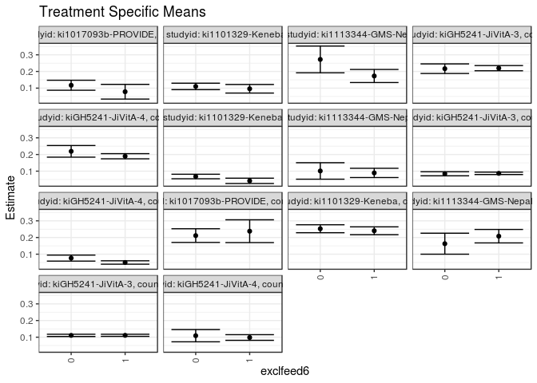

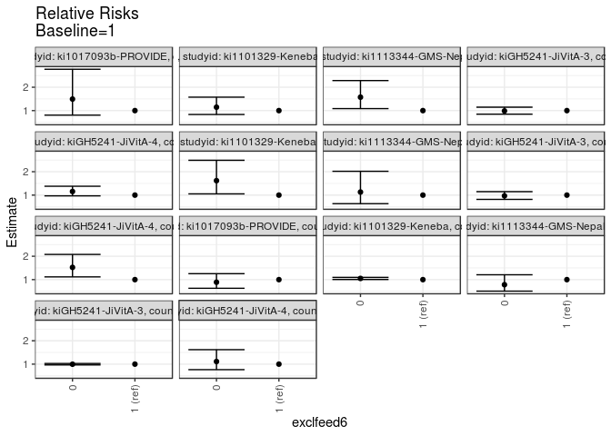

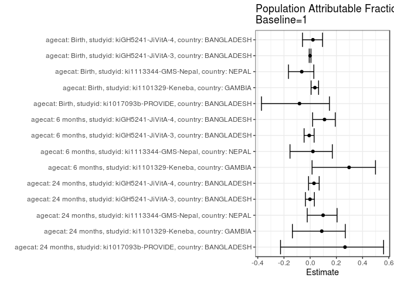

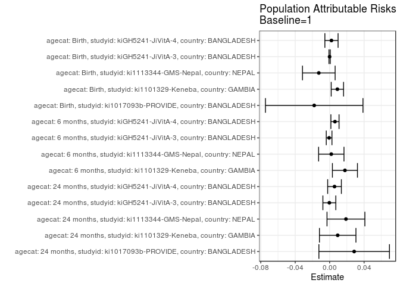

## Results Table

### Parameter: TSM

| agecat | studyid | country | intervention_level | baseline_level | estimate | ci_lower | ci_upper |
| --- | --- | --- | --- | --- | --- | --- | --- |
| Birth | ki1017093b-PROVIDE | BANGLADESH | 1 | NA | 0.2378733 | 0.1695166 | 0.3062300 |
| Birth | ki1017093b-PROVIDE | BANGLADESH | 0 | NA | 0.2114311 | 0.1704200 | 0.2524423 |
| Birth | ki1101329-Keneba | GAMBIA | 1 | NA | 0.2404459 | 0.2169238 | 0.2639680 |
| Birth | ki1101329-Keneba | GAMBIA | 0 | NA | 0.2526229 | 0.2287374 | 0.2765084 |
| Birth | ki1113344-GMS-Nepal | NEPAL | 1 | NA | 0.2080025 | 0.1676689 | 0.2483360 |
| Birth | ki1113344-GMS-Nepal | NEPAL | 0 | NA | 0.1628879 | 0.0999066 | 0.2258691 |
| Birth | kiGH5241-JiVitA-3 | BANGLADESH | 1 | NA | 0.1112906 | 0.1048937 | 0.1176876 |
| Birth | kiGH5241-JiVitA-3 | BANGLADESH | 0 | NA | 0.1108936 | 0.1041450 | 0.1176423 |
| Birth | kiGH5241-JiVitA-4 | BANGLADESH | 1 | NA | 0.0981637 | 0.0811415 | 0.1151859 |
| Birth | kiGH5241-JiVitA-4 | BANGLADESH | 0 | NA | 0.1091363 | 0.0723839 | 0.1458886 |
| 6 months | ki1101329-Keneba | GAMBIA | 1 | NA | 0.0420002 | 0.0259863 | 0.0580140 |
| 6 months | ki1101329-Keneba | GAMBIA | 0 | NA | 0.0679834 | 0.0544036 | 0.0815633 |
| 6 months | ki1113344-GMS-Nepal | NEPAL | 1 | NA | 0.0894964 | 0.0617119 | 0.1172809 |
| 6 months | ki1113344-GMS-Nepal | NEPAL | 0 | NA | 0.1012411 | 0.0518332 | 0.1506489 |
| 6 months | kiGH5241-JiVitA-3 | BANGLADESH | 1 | NA | 0.0870620 | 0.0797773 | 0.0943467 |
| 6 months | kiGH5241-JiVitA-3 | BANGLADESH | 0 | NA | 0.0843708 | 0.0721395 | 0.0966021 |
| 6 months | kiGH5241-JiVitA-4 | BANGLADESH | 1 | NA | 0.0502011 | 0.0399996 | 0.0604026 |
| 6 months | kiGH5241-JiVitA-4 | BANGLADESH | 0 | NA | 0.0764646 | 0.0584473 | 0.0944820 |
| 24 months | ki1017093b-PROVIDE | BANGLADESH | 1 | NA | 0.0786070 | 0.0344852 | 0.1227287 |
| 24 months | ki1017093b-PROVIDE | BANGLADESH | 0 | NA | 0.1174037 | 0.0873411 | 0.1474663 |
| 24 months | ki1101329-Keneba | GAMBIA | 1 | NA | 0.0963388 | 0.0706017 | 0.1220759 |
| 24 months | ki1101329-Keneba | GAMBIA | 0 | NA | 0.1104201 | 0.0911397 | 0.1297006 |
| 24 months | ki1113344-GMS-Nepal | NEPAL | 1 | NA | 0.1729738 | 0.1337030 | 0.2122445 |
| 24 months | ki1113344-GMS-Nepal | NEPAL | 0 | NA | 0.2723849 | 0.1921716 | 0.3525982 |
| 24 months | kiGH5241-JiVitA-3 | BANGLADESH | 1 | NA | 0.2198060 | 0.2041768 | 0.2354352 |
| 24 months | kiGH5241-JiVitA-3 | BANGLADESH | 0 | NA | 0.2167542 | 0.1879119 | 0.2455965 |
| 24 months | kiGH5241-JiVitA-4 | BANGLADESH | 1 | NA | 0.1896067 | 0.1741035 | 0.2051100 |
| 24 months | kiGH5241-JiVitA-4 | BANGLADESH | 0 | NA | 0.2190380 | 0.1840991 | 0.2539768 |

### Parameter: E(Y)

| agecat | studyid | country | intervention_level | baseline_level | estimate | ci_lower | ci_upper |
| --- | --- | --- | --- | --- | --- | --- | --- |
| Birth | ki1017093b-PROVIDE | BANGLADESH | NA | NA | 0.2199248 | 0.1846953 | 0.2551543 |
| Birth | ki1101329-Keneba | GAMBIA | NA | NA | 0.2494348 | 0.2261459 | 0.2727237 |
| Birth | ki1113344-GMS-Nepal | NEPAL | NA | NA | 0.1954023 | 0.1613549 | 0.2294497 |
| Birth | kiGH5241-JiVitA-3 | BANGLADESH | NA | NA | 0.1112249 | 0.1049045 | 0.1175452 |
| Birth | kiGH5241-JiVitA-4 | BANGLADESH | NA | NA | 0.1002698 | 0.0846581 | 0.1158815 |
| 6 months | ki1101329-Keneba | GAMBIA | NA | NA | 0.0597484 | 0.0491105 | 0.0703864 |
| 6 months | ki1113344-GMS-Nepal | NEPAL | NA | NA | 0.0914077 | 0.0672348 | 0.1155805 |
| 6 months | kiGH5241-JiVitA-3 | BANGLADESH | NA | NA | 0.0864198 | 0.0802086 | 0.0926309 |
| 6 months | kiGH5241-JiVitA-4 | BANGLADESH | NA | NA | 0.0563743 | 0.0475411 | 0.0652074 |
| 24 months | ki1017093b-PROVIDE | BANGLADESH | NA | NA | 0.1070812 | 0.0818727 | 0.1322897 |
| 24 months | ki1101329-Keneba | GAMBIA | NA | NA | 0.1056803 | 0.0901896 | 0.1211711 |
| 24 months | ki1113344-GMS-Nepal | NEPAL | NA | NA | 0.1918977 | 0.1562203 | 0.2275751 |
| 24 months | kiGH5241-JiVitA-3 | BANGLADESH | NA | NA | 0.2194592 | 0.2057462 | 0.2331723 |
| 24 months | kiGH5241-JiVitA-4 | BANGLADESH | NA | NA | 0.1952677 | 0.1809764 | 0.2095589 |

### Parameter: RR

| agecat | studyid | country | intervention_level | baseline_level | estimate | ci_lower | ci_upper |
| --- | --- | --- | --- | --- | --- | --- | --- |
| Birth | ki1017093b-PROVIDE | BANGLADESH | 1 | 1 | 1.0000000 | 1.0000000 | 1.000000 |
| Birth | ki1017093b-PROVIDE | BANGLADESH | 0 | 1 | 0.8888393 | 0.6299608 | 1.254102 |
| Birth | ki1101329-Keneba | GAMBIA | 1 | 1 | 1.0000000 | 1.0000000 | 1.000000 |
| Birth | ki1101329-Keneba | GAMBIA | 0 | 1 | 1.0506432 | 1.0065928 | 1.096621 |
| Birth | ki1113344-GMS-Nepal | NEPAL | 1 | 1 | 1.0000000 | 1.0000000 | 1.000000 |
| Birth | ki1113344-GMS-Nepal | NEPAL | 0 | 1 | 0.7831055 | 0.5078918 | 1.207451 |
| Birth | kiGH5241-JiVitA-3 | BANGLADESH | 1 | 1 | 1.0000000 | 1.0000000 | 1.000000 |
| Birth | kiGH5241-JiVitA-3 | BANGLADESH | 0 | 1 | 0.9964326 | 0.9660388 | 1.027783 |
| Birth | kiGH5241-JiVitA-4 | BANGLADESH | 1 | 1 | 1.0000000 | 1.0000000 | 1.000000 |
| Birth | kiGH5241-JiVitA-4 | BANGLADESH | 0 | 1 | 1.1117783 | 0.7641480 | 1.617554 |
| 6 months | ki1101329-Keneba | GAMBIA | 1 | 1 | 1.0000000 | 1.0000000 | 1.000000 |
| 6 months | ki1101329-Keneba | GAMBIA | 0 | 1 | 1.6186462 | 1.0526569 | 2.488955 |
| 6 months | ki1113344-GMS-Nepal | NEPAL | 1 | 1 | 1.0000000 | 1.0000000 | 1.000000 |
| 6 months | ki1113344-GMS-Nepal | NEPAL | 0 | 1 | 1.1312303 | 0.6340422 | 2.018292 |
| 6 months | kiGH5241-JiVitA-3 | BANGLADESH | 1 | 1 | 1.0000000 | 1.0000000 | 1.000000 |
| 6 months | kiGH5241-JiVitA-3 | BANGLADESH | 0 | 1 | 0.9690882 | 0.8182095 | 1.147789 |
| 6 months | kiGH5241-JiVitA-4 | BANGLADESH | 1 | 1 | 1.0000000 | 1.0000000 | 1.000000 |
| 6 months | kiGH5241-JiVitA-4 | BANGLADESH | 0 | 1 | 1.5231677 | 1.1164644 | 2.078024 |
| 24 months | ki1017093b-PROVIDE | BANGLADESH | 1 | 1 | 1.0000000 | 1.0000000 | 1.000000 |
| 24 months | ki1017093b-PROVIDE | BANGLADESH | 0 | 1 | 1.4935536 | 0.8056443 | 2.768842 |
| 24 months | ki1101329-Keneba | GAMBIA | 1 | 1 | 1.0000000 | 1.0000000 | 1.000000 |
| 24 months | ki1101329-Keneba | GAMBIA | 0 | 1 | 1.1461651 | 0.8339820 | 1.575207 |
| 24 months | ki1113344-GMS-Nepal | NEPAL | 1 | 1 | 1.0000000 | 1.0000000 | 1.000000 |
| 24 months | ki1113344-GMS-Nepal | NEPAL | 0 | 1 | 1.5747181 | 1.0856239 | 2.284159 |
| 24 months | kiGH5241-JiVitA-3 | BANGLADESH | 1 | 1 | 1.0000000 | 1.0000000 | 1.000000 |
| 24 months | kiGH5241-JiVitA-3 | BANGLADESH | 0 | 1 | 0.9861161 | 0.8481154 | 1.146572 |
| 24 months | kiGH5241-JiVitA-4 | BANGLADESH | 1 | 1 | 1.0000000 | 1.0000000 | 1.000000 |
| 24 months | kiGH5241-JiVitA-4 | BANGLADESH | 0 | 1 | 1.1552226 | 0.9678706 | 1.378840 |

### Parameter: PAR

| agecat | studyid | country | intervention_level | baseline_level | estimate | ci_lower | ci_upper |
| --- | --- | --- | --- | --- | --- | --- | --- |
| Birth | ki1017093b-PROVIDE | BANGLADESH | 1 | NA | -0.0179485 | -0.0745730 | 0.0386760 |
| Birth | ki1101329-Keneba | GAMBIA | 1 | NA | 0.0089889 | 0.0018224 | 0.0161554 |
| Birth | ki1113344-GMS-Nepal | NEPAL | 1 | NA | -0.0126002 | -0.0315567 | 0.0063564 |
| Birth | kiGH5241-JiVitA-3 | BANGLADESH | 1 | NA | -0.0000658 | -0.0008139 | 0.0006824 |
| Birth | kiGH5241-JiVitA-4 | BANGLADESH | 1 | NA | 0.0021061 | -0.0055673 | 0.0097795 |
| 6 months | ki1101329-Keneba | GAMBIA | 1 | NA | 0.0177482 | 0.0032033 | 0.0322932 |
| 6 months | ki1113344-GMS-Nepal | NEPAL | 1 | NA | 0.0019113 | -0.0128092 | 0.0166317 |
| 6 months | kiGH5241-JiVitA-3 | BANGLADESH | 1 | NA | -0.0006423 | -0.0039500 | 0.0026655 |
| 6 months | kiGH5241-JiVitA-4 | BANGLADESH | 1 | NA | 0.0061732 | 0.0014372 | 0.0109092 |
| 24 months | ki1017093b-PROVIDE | BANGLADESH | 1 | NA | 0.0284742 | -0.0125100 | 0.0694585 |
| 24 months | ki1101329-Keneba | GAMBIA | 1 | NA | 0.0093415 | -0.0118452 | 0.0305282 |
| 24 months | ki1113344-GMS-Nepal | NEPAL | 1 | NA | 0.0189239 | -0.0030615 | 0.0409092 |
| 24 months | kiGH5241-JiVitA-3 | BANGLADESH | 1 | NA | -0.0003468 | -0.0078436 | 0.0071500 |
| 24 months | kiGH5241-JiVitA-4 | BANGLADESH | 1 | NA | 0.0056610 | -0.0022942 | 0.0136161 |

### Parameter: PAF

| agecat | studyid | country | intervention_level | baseline_level | estimate | ci_lower | ci_upper |
| --- | --- | --- | --- | --- | --- | --- | --- |
| Birth | ki1017093b-PROVIDE | BANGLADESH | 1 | NA | -0.0816119 | -0.3717969 | 0.1471884 |
| Birth | ki1101329-Keneba | GAMBIA | 1 | NA | 0.0360370 | 0.0070913 | 0.0641389 |
| Birth | ki1113344-GMS-Nepal | NEPAL | 1 | NA | -0.0644832 | -0.1657346 | 0.0279740 |
| Birth | kiGH5241-JiVitA-3 | BANGLADESH | 1 | NA | -0.0005913 | -0.0073393 | 0.0061114 |
| Birth | kiGH5241-JiVitA-4 | BANGLADESH | 1 | NA | 0.0210042 | -0.0584793 | 0.0945192 |
| 6 months | ki1101329-Keneba | GAMBIA | 1 | NA | 0.2970496 | 0.0145868 | 0.4985461 |
| 6 months | ki1113344-GMS-Nepal | NEPAL | 1 | NA | 0.0209093 | -0.1539794 | 0.1692931 |
| 6 months | kiGH5241-JiVitA-3 | BANGLADESH | 1 | NA | -0.0074319 | -0.0463995 | 0.0300846 |
| 6 months | kiGH5241-JiVitA-4 | BANGLADESH | 1 | NA | 0.1095039 | 0.0186996 | 0.1919056 |
| 24 months | ki1017093b-PROVIDE | BANGLADESH | 1 | NA | 0.2659125 | -0.2262456 | 0.5605411 |
| 24 months | ki1101329-Keneba | GAMBIA | 1 | NA | 0.0883943 | -0.1357097 | 0.2682769 |
| 24 months | ki1113344-GMS-Nepal | NEPAL | 1 | NA | 0.0986145 | -0.0223736 | 0.2052849 |
| 24 months | kiGH5241-JiVitA-3 | BANGLADESH | 1 | NA | -0.0015801 | -0.0363297 | 0.0320044 |
| 24 months | kiGH5241-JiVitA-4 | BANGLADESH | 1 | NA | 0.0289908 | -0.0124085 | 0.0686971 |